# CM 3015 Machine Learning and Neural Networks Final Project - Vehicle Identification with CIFAR-10

# I. Introduction

In today's everchanging society, the advancement of technology is growing very fast. Smart devices are now available in many forms such as phones, tablets, and vehicles. The problem we will be discussing today is correlated to smart vehicles. In theory, smart vehicles should be able to drive themselves without human assistance. But as of now in 2024, it is not fully a reality yet.

One of the main problems of automated smart vehicles is safety. The vehicle should be able to drive as if a human is driving. So, it should be able to identify other vehicles on the road to prevent accidents. In this project, I aim to train a machine how to do vehicle identification with the CIFAR-10 dataset.

The CIFAR-10 dataset includes 10 classes (airplane, automobile, bird, cat, deer, dog, frog, horse, ship, truck) and 60.000 images. It contains 6000 images per class with a size of 32x32. For this project, we are just going to focus on 4 vehicle classes which are airplanes, automobiles, ships, and trucks. In total, 24.000 images will be used for this project. Not all of these vehicles are meant to be driven on the road but it is a good starting point.

I am going to conduct this project based on the Universal Flow of Machine Learning of DLWP 4.5 (1st edition) (https://bookdown.org/paul/2021_computational_social_science/the-universal-workflow-of-machine-learning.html).

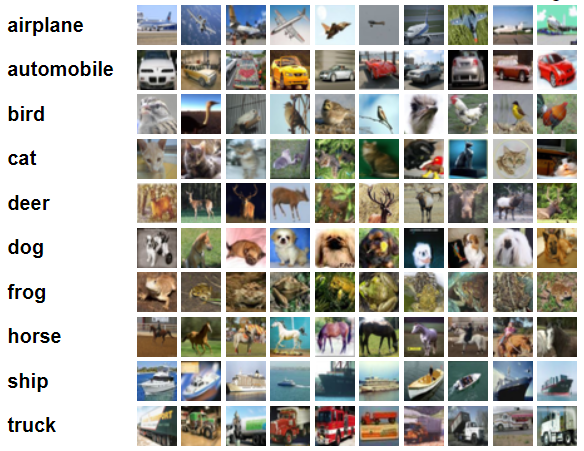

```python
'''install if necessary'''
#!pip install visualkeras
```

```
'install if necessary'
```

```python
'''Lets start by importing the modules we are going to use for this project'''
import matplotlib.pyplot as plt
import numpy as np
import cv2
import urllib.request
%matplotlib inline

# for neater outputs
import warnings
warnings.filterwarnings('ignore')

# Machine Learning modules
import tensorflow as tf
from tensorflow.keras.datasets import cifar10
from sklearn.model_selection import train_test_split
from sklearn.metrics import classification_report
from tensorflow.keras.optimizers import Adam
from keras.preprocessing.image import ImageDataGenerator
from keras.utils import to_categorical
from keras.models import Sequential
from keras.layers import Dense, Conv2D, MaxPooling2D, Dropout, Flatten, BatchNormalization
from tensorflow.keras import layers, models, regularizers
import visualkeras
```

```
WARNING:tensorflow:From C:\Users\William\anaconda3\lib\site-packages\keras\src\losses.py:2976: The name tf.losses.sparse_softmax_cross_entropy is deprecated. Please use tf.compat.v1.losses.sparse_softmax_cross_entropy instead.
```

## Methodology of Training and Testing

The steps that will be taken for this experiment include:

1. Import necessary modules and dataset to the project. For this project, it is the CIFAR-10 dataset.
2. Pre-process data in order to be suitable for the models (Normalization, One-hot encoding, and Data augmentation).
3. Complete Naive Bayes baseline test to acquire baseline accuracy. The result will be the minimum target requirement.
4. Design 2 models, a simple one and an overfit one.
5. Train the models with the dataset, while experimenting with parameters (epochs, batch size, learning rate).
6. Test and evaluate the models, visualize the results, and do validation test with external data.
7. Create a new model, adding optimization to the overfit model to get rid of the overfitting (on the assumption that it performs better than the simple model).
8. Repeat step 5 and 6.

## Aims and Objectives

The metrics to measure the success of the project include:

- Accuracy (Naive baseline or above):
  - Training Accuracy (train data + data augmentation)
  - Validation Accuracy (val data + data augmentation)
  - Evaluation Score accuracy (test data (pure))
- Minimize overfitting and noise (jagged lines) as much as possible.
- Observe the loss graph and make sure it goes down.

The aims and objectives of this project include:

1. Importing and understanding the CIFAR-10 dataset to use for building a neural network.
2. Develop 2 models, 1 simple and 1 deep model, using only Sequential, Dense, and Dropout layers.
3. Train, test, and validate models.
4. Optimize overfit model, as a separate model.
5. By the end of the experiment, the models should surpass Naive baseline accuracy (without CNN).
6. Conclude factors to making an optimal model.

## Import CIFAR-10 and load only the vehicle classes

```
X_train size: (16000, 32, 32, 3)
X_test size: (4000, 32, 32, 3)
X_valid size: (4000, 32, 32, 3)


y_train size: (16000, 1)
y_test size: (4000, 1)
y_valid size: (4000, 1)
```

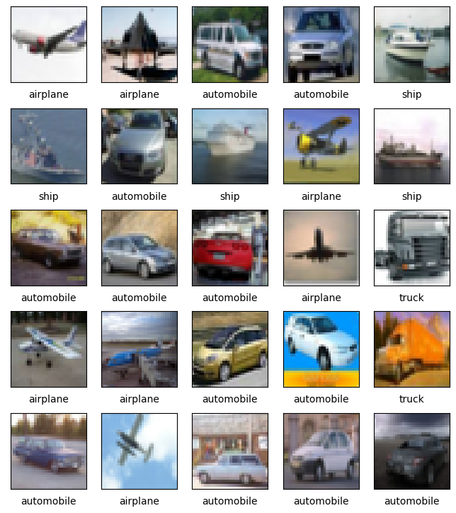

```python
# Load CIFAR-10 dataset
(X_train, y_train), (X_test, y_test) = cifar10.load_data()

# Define the classes you want to keep (e.g., airplane, automobile, ship, truck)
vehicle_index = [0, 1, 8, 9]  # indices of airplane, automobile, ship, truck

# Filter the training set
train_mask = np.isin(y_train, vehicle_index)
X_train = X_train[train_mask[:, 0]]
y_train = y_train[train_mask[:, 0]]

# Filter the test set
test_mask = np.isin(y_test, vehicle_index)
X_test = X_test[test_mask[:, 0]]
y_test = y_test[test_mask[:, 0]]

# Split the training set into training and validation sets
X_train, X_valid, y_train, y_valid = train_test_split(
    X_train, y_train, test_size=0.2, random_state=42)

# Print the sizes of the filtered datasets
print('X_train size:', X_train.shape)
print('X_test size:', X_test.shape)
print('X_valid size:', X_valid.shape)

print('\n')
print('y_train size:', y_train.shape)
print('y_test size:', y_test.shape)
print('y_valid size:', y_valid.shape)

# Define the class names
# class_names = ['airplane', 'automobile', 'bird', 'cat', 'deer', 'dog', 'frog', 'horse', 'ship', 'truck']
class_names = {0: 'airplane', 1: 'automobile', 8: 'ship', 9: 'truck'}

# Display the images with class names
start_index = 1000
end_index = min(start_index + 25, len(X_train))

plt.figure(figsize=(8, 9))
for i in range(start_index, end_index):
    plt.subplot(5, 5, i - start_index + 1)
    plt.xticks([])
    plt.yticks([])
    plt.grid(False)
    plt.imshow(X_train[i])
    plt.xlabel(class_names[y_train[i][0]])  # Use the class name as label
plt.show()
```

# II. Data Pre-processing

#### Before training the model, we have to pre-process and prepare the data in order for it to be suitable for the model. Some of the pre-processing done include:

- Do normalization. Turn X data into floats between 0-1.
- Do one-hot encoding. Turn y data (target) into categorical data.
- Perform data augmentation to 'simulate' a more variative training data. Since I have cut down the training data by a significant amount, it is wise to do this in order to simulate a larger dataset.

```python
# Convert all X values into floats
'''Normalization'''
X_train = X_train.astype('float32') / 255
X_test = X_test.astype('float32') / 255
X_valid = X_valid.astype('float32') / 255
```

```python
# Convert y labels into categorical data
'''One hot encoding.'''
y_train = to_categorical(y_train, num_classes=10)
y_test = to_categorical(y_test, num_classes=10)
y_valid = to_categorical(y_valid, num_classes=10)
```

```python
# Print the sizes of the filtered datasets
print('X_train size:', X_train.shape)
print('X_test size:', X_test.shape)
print('X_valid size:', X_valid.shape)

print('\n')
print('y_train size:', y_train.shape)
print('y_test size:', y_test.shape)
print('y_valid size:', y_valid.shape)
```

```
X_train size: (16000, 32, 32, 3)
X_test size: (4000, 32, 32, 3)
X_valid size: (4000, 32, 32, 3)


y_train size: (16000, 10)
y_test size: (4000, 10)
y_valid size: (4000, 10)
```

```python
# Data augmentation
'''data augmentation'''
data_augmentation = ImageDataGenerator(
    # rotate images randomly
    rotation_range=10,

    # shift images horizontally
    width_shift_range=0.1,

    # Shift images vertically
    height_shift_range=0.1,

    # random horizontal flip
    horizontal_flip=True,

    # Zoom images
    zoom_range=0.1,

)
```

# III. Determining baseline accuracy using Naive Baseline Accuracy

Before making the Neural networks, I need to determine the baseline target for the experiment with Naive Baseline. Naïve Bayes assumes a generative model for each class. Then, these generative models predict labels for new points. It is a good starting point/baseline for classification tasks.

```python
from sklearn.naive_bayes import GaussianNB
from sklearn.metrics import accuracy_score

# Create a Gaussian Naive Bayes classifier
clf = GaussianNB()

# turn into 1d array for this baseline
X_train_baseline = X_train.reshape(X_train.shape[0], -1)
X_test_baseline = X_test.reshape(X_test.shape[0], -1)

y_train_baseline = y_train.argmax(axis=1)
y_test_baseline = y_test.argmax(axis=1)

# train the classifier on flattened training data
clf.fit(X_train_baseline, y_train_baseline)

# make predictions on flattened test data
y_pred = clf.predict(X_test_baseline)

# calculate the accuracy of the predictions (baseline score)
baseline_accuracy = accuracy_score(y_test_baseline, y_pred)

print("The baseline accuracy for this project is: {:.2f}%".format(baseline_accuracy * 100))
```

```
The baseline accuracy for this project is: 50.12%
```

The percentage above must be achieved by the models and a higher accuracy is favorable.

Additionally, a study from Montreal University Canada was conducted in 2016, training models with the CIFAR-10 dataset without any CNN layers. The results of the study were that an accuracy of 55% - 70% can be achieved depending on various parameters and tuning. But, an accuracy of 90% is simply impossible without ConvNet layers. So I may aim for 60%+ accuracy for this project.

# IV. Training, Testing, and Evaluating Models

I will be developing 3 models, a simple, overfit, and most optimal model based on the results of the previous 2 models. The metric to grade the models will be accuracy. A history graph will be observed to determine overfitting. Additionally, a testing/validation process is done with some external images outside the database to see how the models will fair against the foreign data.

The layers will have relu activation, the last layer will be soft max, and categorical_crossentropy will be used for the loss function. categorical_crossentropy is used because the dataset is multi-class, but single-label.

Adam will be used for the optimizer.

These metrics will be used for all models to achieve consistent results across the board.

## A. Simple shallow model

- has flatten layer to convert array to 1D.
- has 2 Dense layers, to apply relu and softmax.
- Practically only 1 layer does the filtering.
- Results will most likely be overfit

```python
'''simple model. 1 block'''
simple_model = Sequential([
    Flatten(input_shape=(32,32,3)),
    Dense(128, activation='relu'),
    Dense(10, activation='softmax')
], name = 'simple_model')

simple_model.summary()
```

```
WARNING:tensorflow:From C:\Users\William\anaconda3\lib\site-packages\keras\src\backend.py:873: The name tf.get_default_graph is deprecated. Please use tf.compat.v1.get_default_graph instead.

Model: "simple_model"
_________________________________________________________________
 Layer (type)                Output Shape              Param #
=================================================================
 flatten (Flatten)           (None, 3072)              0

 dense (Dense)               (None, 128)               393344

 dense_1 (Dense)             (None, 10)                1290

=================================================================
Total params: 394634 (1.51 MB)
Trainable params: 394634 (1.51 MB)
Non-trainable params: 0 (0.00 Byte)
_________________________________________________________________
```

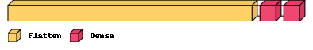

```python
# visualize model
visualkeras.layered_view(simple_model, scale_xy=10, legend=True)
```

### Compiling and training the model.

The batch_size, epochs, and learning_rate are customizable so I can play with them during development. A validation dataset is also available. This allows the model to test itself on unseen data on every epoch/step of training.

```python
# compile and train model

# modify parameters
batch_size = 64
epochs = 10 # how many times to train
learning_rate = 0.001

simple_model.compile(optimizer=Adam(learning_rate=learning_rate),
                    loss='categorical_crossentropy',
                    metrics=['accuracy'])

# Train model
# Train the model
history_simple = simple_model.fit(data_augmentation.flow(X_train, y_train, batch_size=batch_size),
                    epochs=epochs,
                 validation_data=data_augmentation.flow(X_valid, y_valid),
                   )
```

[output not shown]

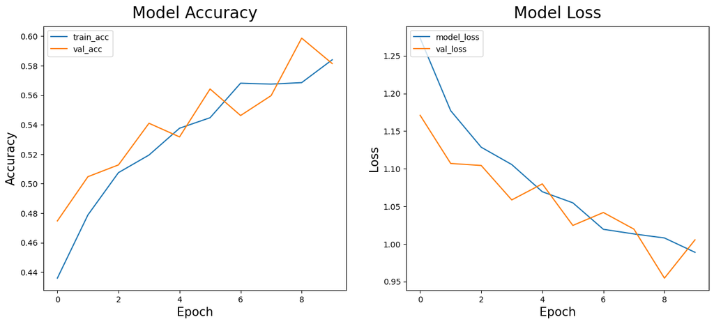

```python
# Plotting the Model Accuracy & Model Loss vs Epochs
plt.figure(figsize=[15,6])

# MODEL ACCURACY
plt.subplot(1,2,1)
plt.plot(history_simple.history['accuracy'])
plt.plot(history_simple.history['val_accuracy'])
plt.title('Model Accuracy', size=20, pad=10)
plt.ylabel('Accuracy', size=15)
plt.xlabel('Epoch', size=15)
plt.legend(['train_acc', 'val_acc'], loc='upper left')

# MODEL LOSS
plt.subplot(1,2,2)
plt.plot(history_simple.history['loss'])
plt.plot(history_simple.history['val_loss'])
plt.title('Model Loss', size=20, pad=10)
plt.ylabel('Loss', size=15)
plt.xlabel('Epoch', size=15)
plt.legend(['model_loss', 'val_loss'], loc='upper left')
plt.show()
```

This model is too simple. Jagged lines suggests that it is undertrained because of the small number of epochs. Needs to be improved

```python
'''use the testing data to evaluate model'''
simple_scores = simple_model.evaluate(X_test, y_test)
print('Test loss:', simple_scores[0])
print('Test accuracy:', simple_scores[1])
```

```
Test loss: 0.954637885093689
Test accuracy: 0.6222500205039978
```

The accuracy scores surpass the baseline accuracy of 50.12%. The test accuracy is higher than the training and validation accuracy because it is tested on data that didn't go through data augmention. This may be a trend for the succeeding models as well.

### Validation

#### Test the model out on a completely random images outside the dataset

```python
# function to validate model against random images
def validate_model(urls, model, class_names):
    for url in urls:
        resp = urllib.request.urlopen(url)
        image = np.asarray(bytearray(resp.read()), dtype="uint8")
        image = cv2.imdecode(image, cv2.IMREAD_UNCHANGED)

        # Convert the image from BGR to RGB
        image = cv2.cvtColor(image, cv2.COLOR_BGR2RGB)

        # Resize it to 32x32 pixels
        image = cv2.resize(image, (32,32))

        # Normalize the image
        image = image/255

        # Add an extra dimension because the model expects a batch of images
        image = image.reshape((1, 32, 32, 3))

        # Predict the class
        prediction = model.predict(image)
        predicted_class = prediction.argmax()

        # Display the image as well
        plt.imshow(image.reshape(32, 32, 3))
        plt.title(f'Predicted class: {class_names[predicted_class]}')
        plt.axis('off')
        plt.show()
```

```python
# image sources
urls = [
    'https://upload.wikimedia.org/wikipedia/commons/a/a4/2019_Toyota_Corolla_Icon_Tech_VVT-i_Hybrid_1.8.jpg',
    'https://t3.ftcdn.net/jpg/01/23/52/24/360_F_123522471_XZe5ebqil1DFJRgOUJ6taDP4DnmHjtL7.jpg',
    'https://www.cnet.com/a/img/resize/ccfa703693ff23e65d52831cd14852a5bb91f68a/hub/2016/01/05/a3d8185a-0456-42ce-9d55-e2b3b5ff00d0/optimus.png?auto=webp&fit=crop&height=675&width=1200',
    'https://bwtf.com/sites/default/files/2023-06/1.jpg',
    'https://upload.wikimedia.org/wikipedia/commons/0/0f/OO-FLN.JPG',
    'https://www.tessllc.us/wp-content/uploads/2020/07/yacht-post-825x510.jpg'
]
```

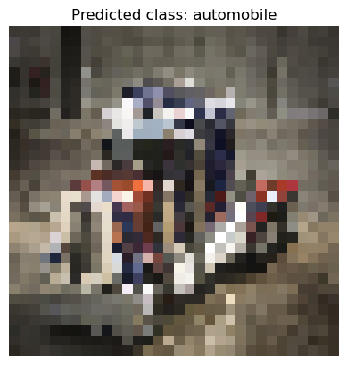

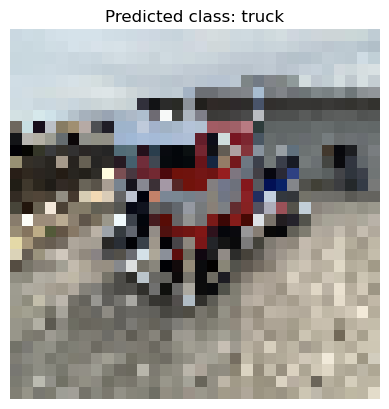

```python
# Test out 1st model
validate_model(urls, simple_model, class_names)
```

### Validation Results: 4/6

# B. Developing a deeper model

- has 4 Dense relu layers to try overfitting the models.
- Designed Dense layers from big to small.
- No optimizers included. Let's see how it goes.

```python
# # Second model
overfit_model = Sequential([
                    Flatten(input_shape=(32,32,3)),
                    Dense(128, activation='relu'),
                    Dense(64, activation='relu'),
                    Dense(32, activation='relu'),
                    Dense(16, activation='relu'),
                    Dense(10, activation='softmax')
], name='overfit_model')

overfit_model.summary()
```

```
Model: "overfit_model"
_________________________________________________________________
 Layer (type)                Output Shape              Param #
=================================================================
 flatten_1 (Flatten)         (None, 3072)              0

 dense_2 (Dense)             (None, 128)               393344

 dense_3 (Dense)             (None, 64)                8256

 dense_4 (Dense)             (None, 32)                2080

 dense_5 (Dense)             (None, 16)                528

 dense_6 (Dense)             (None, 10)                170

=================================================================
Total params: 404378 (1.54 MB)
Trainable params: 404378 (1.54 MB)
Non-trainable params: 0 (0.00 Byte)
_________________________________________________________________
```

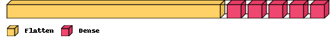

```python
# visualize 2nd model
visualkeras.layered_view(overfit_model, scale_xy=10, legend=True)
```

### Compiling and training the model.

The batch_size, epochs, and learning_rate are customizable so I can play with them during development. A validation dataset is also available. This allows the model to test itself on unseen data on every epoch/step of training.

The parameters have been upgraded from the previous training to improve results even further.

```python
# Define the number of epochs and learning rate
epochs = 40
learning_rate = 0.001
batch_size = 256

# Compile the model
overfit_model.compile(optimizer=Adam(learning_rate=learning_rate),
              loss='categorical_crossentropy',
              metrics=['accuracy'])


# Train the model
history_overfit = overfit_model.fit(data_augmentation.flow(X_train, y_train, batch_size=batch_size),
                    epochs=epochs,
                     validation_data=data_augmentation.flow(X_valid, y_valid),
                   )
```

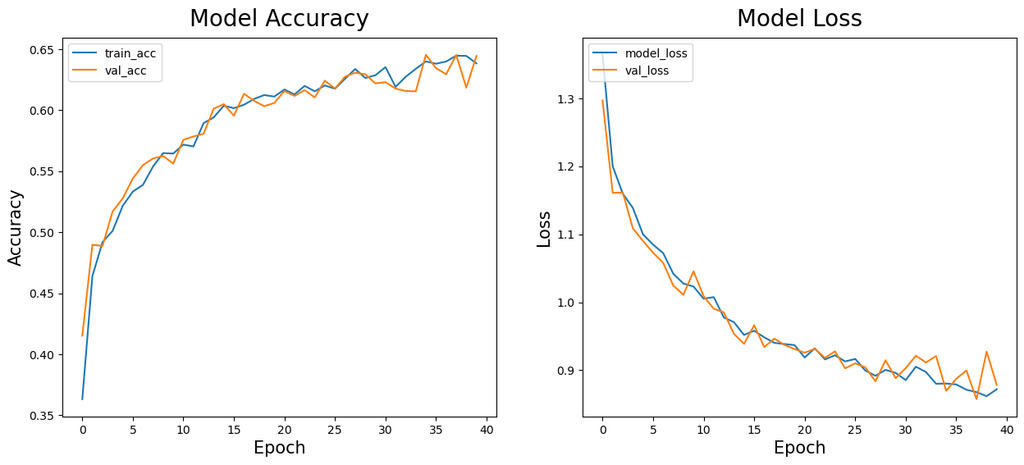

```python
# Plotting the Model Accuracy & Model Loss vs Epochs
plt.figure(figsize=[15,6])

# MODEL ACCURACY
plt.subplot(1,2,1)
plt.plot(history_overfit.history['accuracy'])
plt.plot(history_overfit.history['val_accuracy'])
plt.title('Model Accuracy', size=20, pad=10)
plt.ylabel('Accuracy', size=15)
plt.xlabel('Epoch', size=15)
plt.legend(['train_acc', 'val_acc'], loc='upper left')

# MODEL LOSS
plt.subplot(1,2,2)
plt.plot(history_overfit.history['loss'])
plt.plot(history_overfit.history['val_loss'])
plt.title('Model Loss', size=20, pad=10)
plt.ylabel('Loss', size=15)
plt.xlabel('Epoch', size=15)
plt.legend(['model_loss', 'val_loss'], loc='upper left')
plt.show()
```

The model looks good. The overfitting is not too prominent although the jagged lines may suggest slight overfitting happening, and that the parameters of the training (batch size and learning rate) need to be altered to train it better. Optimization is also needed. Validation accuracy is also higher than the training acuracy, indicating overfitting/overtraining as well.

```python
'''evaluate model using test data'''
overfit_scores = overfit_model.evaluate(X_test, y_test)
print('Test loss:', overfit_scores[0])
print('Test accuracy:', overfit_scores[1])
```

```
Test loss: 0.816996693611145
Test accuracy: 0.671999990940094
```

The accuracy scores surpass the baseline accuracy of 50.12%. The test accuracy is higher than the training and validation accuracy because it is tested on data that didn't go through data augmention. The scores are also already better than the 1st NN model.

### Validation

#### Test the model out on a completely random images outside the dataset

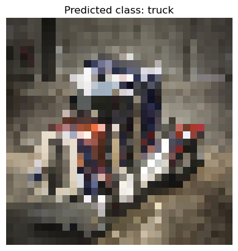

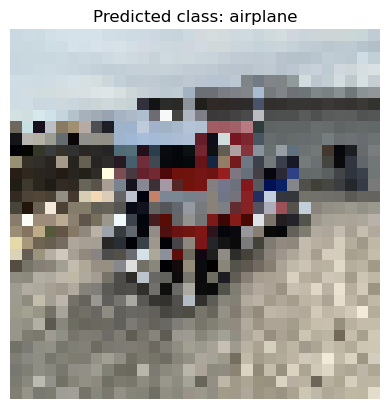

```python
# From the same function, test the 2nd model
validate_model(urls, overfit_model, class_names)
```

### Validation Results: 4/6

Results suggests that not much difference is achieved from the previous model.

# C. Optimized Model (from the overfit)

- Take the overfit model and add optimizer (Dropout layer) to try reducing the overfitting.
- Tweaked the parameters (learning rate and batch size) to reduce jagged lines.

```python
# from tensorflow.keras import layers, models, regularizers

optimized_model = Sequential([
                    Flatten(input_shape=(32, 32, 3)),
                    Dense(128, activation='relu'),
                    Dense(64, activation='relu'),
                    Dropout(0.1),
                    Dense(32, activation='relu'),
                    Dense(16, activation='relu'),
                    Dense(10, activation='softmax'),
], name='optimized_model')

optimized_model.summary()
```

```
Model: "optimized_model"
_________________________________________________________________
 Layer (type)                Output Shape              Param #
=================================================================
 flatten_2 (Flatten)         (None, 3072)              0

 dense_7 (Dense)             (None, 128)               393344

 dense_8 (Dense)             (None, 64)                8256

 dropout (Dropout)           (None, 64)                0

 dense_9 (Dense)             (None, 32)                2080

 dense_10 (Dense)            (None, 16)                528

 dense_11 (Dense)            (None, 10)                170

=================================================================
Total params: 404378 (1.54 MB)
Trainable params: 404378 (1.54 MB)
Non-trainable params: 0 (0.00 Byte)
_________________________________________________________________
```

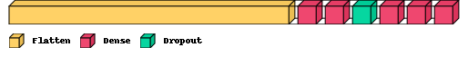

```python
# visualize 2nd model
visualkeras.layered_view(optimized_model, scale_xy=10, legend=True)
```

### Compiling and training the model.

The batch_size, epochs, and learning_rate are customizable so I can play with them during development. A validation dataset is also available. This allows the model to test itself on unseen data on every epoch/step of training.

The parameters have been upgraded from the previous training to improve results even further.

```python
# Define the number of epochs and learning rate
epochs = 40
learning_rate = 0.0005
batch_size = 256

# Compile the model
optimized_model.compile(optimizer=Adam(learning_rate=learning_rate),
              loss='categorical_crossentropy',
              metrics=['accuracy'])


# Train the model
history_optimized = optimized_model.fit(data_augmentation.flow(X_train, y_train, batch_size=batch_size),
                                         epochs=epochs,
                                         validation_data=data_augmentation.flow(X_valid, y_valid),
                                         )
```

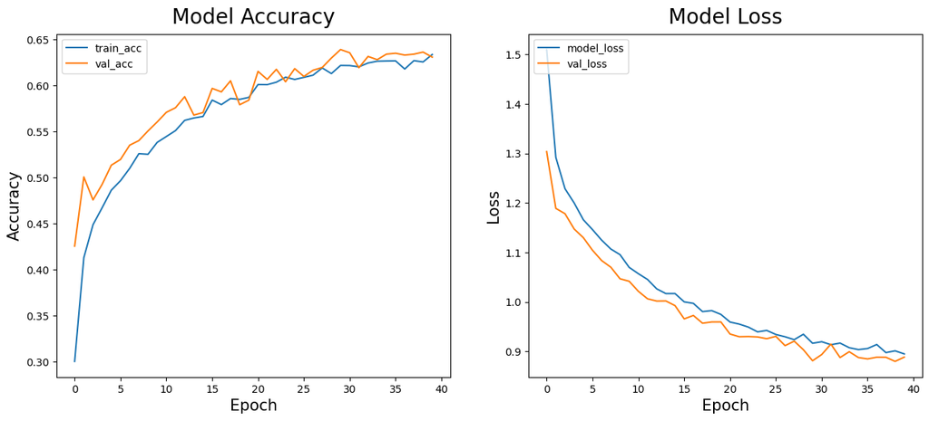

```python
# Plotting the Model Accuracy & Model Loss vs Epochs
plt.figure(figsize=[15,6])

# MODEL ACCURACY
plt.subplot(1,2,1)
plt.plot(history_optimized.history['accuracy'])
plt.plot(history_optimized.history['val_accuracy'])
plt.title('Model Accuracy', size=20, pad=10)
plt.ylabel('Accuracy', size=15)
plt.xlabel('Epoch', size=15)
plt.legend(['train_acc', 'val_acc'], loc='upper left')

# MODEL LOSS
plt.subplot(1,2,2)
plt.plot(history_optimized.history['loss'])
plt.plot(history_optimized.history['val_loss'])
plt.title('Model Loss', size=20, pad=10)
plt.ylabel('Loss', size=15)
plt.xlabel('Epoch', size=15)
plt.legend(['model_loss', 'val_loss'], loc='upper left')
plt.show()
```

The dropout layer and the changes in parameter managed to improve the noise (jagged line) problem in the previous model. The validation accuracy also managed to drop, to balance out the training accuracy.

```python
'''evaluate model using test data'''
optimized_scores = optimized_model.evaluate(X_test, y_test)
print('Test loss:', optimized_scores[0])
print('Test accuracy:', optimized_scores[1])
```

```
Test loss: 0.8261560797691345
Test accuracy: 0.6669999957084656
```

The accuracy scores surpass the baseline accuracy of 50.12%. The results are similar to the overfit one.

### Validation

#### Test the model out on a completely random images outside the dataset

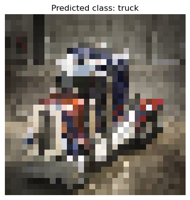

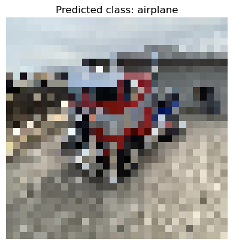

```python
# From the same function, test the optimized model
validate_model(urls, optimized_model, class_names)
```

### Validation Results: 4/6

# V. RESULTS AND CONCLUSION

Evaluation Results:

- Simple: 62.2%
- Overfit: 67.2%
- Optimized: 66.7%

After countless trial and errors, I completed the experiment where all the models surpass the naive baseline accuracy (50.12%). They all surpassed the baseline target by more than 10%.

The results from this experiment suggests that the overfit model is the most consistently accurate model. The optimized model has a dropout layer in between the Dense layers and was trained differently, resulting in less overfitting but sacrificing a little bit of accuracy in the process. The optimization done seemed to have helped in reducing noise (jagged lines) in the graph.

It is important to remember that the CIFAR-10 is a complex dataset and using only Sequential, Dense, and Dropout layers does not do the dataset justice when creating a model. CNN is needed for an exceptionally accurate model.

In conclusion, adding many layers to train a complex dataset such as the CIFAR-10 is the solution to achieving better results. Optimizing it with dropout layers is advisable to reduce noise and overfitting as well as optimizing the training process. However, this process will most likely reduce a bit of accuracy in the process, and making the choice of optimization dependent on the user's needs.

# REFERENCES

Lin, Z., Memisevic, R., & Konda, K. (n.d.). HOW FAR CAN WE GO WITHOUT CONVOLUTION: IMPROVING FULLY-CONNECTED NETWORKS. Cited from: https://openreview.net/pdf/1WvovwjA7UMnPB1oinBL.pdf

Bauer, P. C. (2021, June 17). Computational social science: Theory & application. 8.12 The universal workflow of machine learning. https://bookdown.org/paul/2021_computational_social_science/the-universal-workflow-of-machine-learning.html

CIFAR10 : tensorflow datasets. TensorFlow. (n.d.). https://www.tensorflow.org/datasets/catalog/cifar10

#### Image Sources:

- https://upload.wikimedia.org/wikipedia/commons/a/a4/2019_Toyota_Corolla_Icon_Tech_VVT-i_Hybrid_1.8.jpg
- https://t3.ftcdn.net/jpg/01/23/52/24/360_F_123522471_XZe5ebqil1DFJRgOUJ6taDP4DnmHjtL7.jpg
- https://www.cnet.com/a/img/resize/ccfa703693ff23e65d52831cd14852a5bb91f68a/hub/2016/01/05/a3d8185a-0456-42ce-9d55-e2b3b5ff00d0/optimus.png?auto=webp&fit=crop&height=675&width=1200
- https://bwtf.com/sites/default/files/2023-06/1.jpg
- https://upload.wikimedia.org/wikipedia/commons/0/0f/OO-FLN.JPG
- https://www.tessllc.us/wp-content/uploads/2020/07/yacht-post-825x510.jpg